# act_report

## Report: Insights and Visualizations (WeRateDogs)

#### By Timilehin Adegbamigbe

August, 2022

### Analysis and Visualization

In this report, I'll walk through some insights and visualizations gleaned from the analysis of the tweet archive of [@dog_rates](https://twitter.com/dog_rates), also known as WeRateDogs. WeRateDogs is a popular Twitter account known for humorously rating internet dogs on a scale of ten.

### Insights:

1. What are the most common dog names?
   - *Cooper, Lucy, Oliver, Tucker and Charlie (top 5)*
2. What are the most common dog breeds?
   - *Golden Retriever, Labrador Retriever, Chihuahua, Pembroke, Pug (top 5)*
3. What are the most highly rated dog breeds?
   - *Lakeland Terrier, Pembroke, Wire-Haired Fox Terrier, Standard Schnauzer, Bouvier Des Flandres (top 5)*
4. What are the most highly retweeted/favorited dog breeds?
   - *Golden Retriever, Pembroke, Labrador Retriever, Chihuahua, Chow (top 5)*
5. What is the most common of the various dog stages?
   - *Pupper, Doggo, Puppo (top 3)*
6. On what days of the week do tweets receive the most retweets or favorites on average?
   - *Retweets: Saturday, Wednesday, Friday, Favorites: Wednesday, Saturday, Tuesday (top 3 each)*
7. What are the most favorited Golden Retriever ratings?
   - *Golden Retriever Father-Son duo, Ken, Jack and Klein (top 4)*
8. What is the most favorited dog rating?
   - *A video of an unnamed Shetland Sheepdog standing in a swimming pool [tweet_id: 744234799360020481](https://twitter.com/dog_rates/status/744234799360020481)*

### Visualizations

- While there were 2300+ original ratings in the datset, there were far less mentions of the dog stages in those ratings. Let's look at the distribution of those mentions.

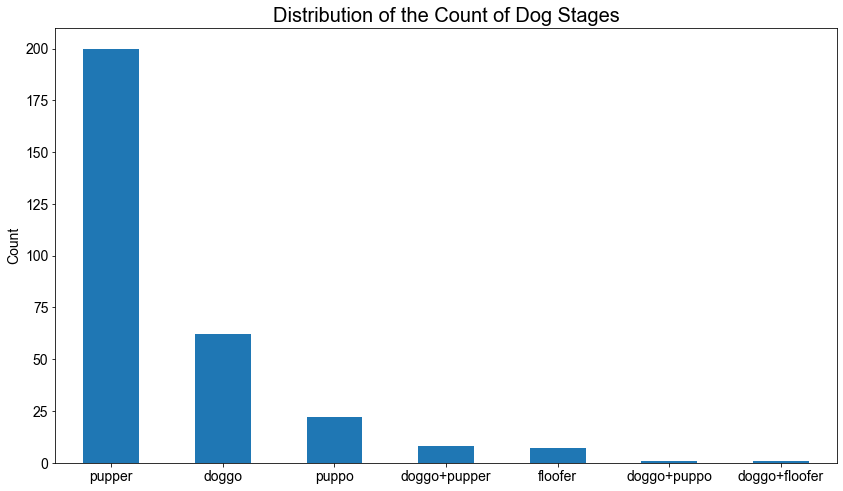

  We can see that "pupper" is the dog stage mentioned by a stretch with 200 identified mentions, followed by "doggo" with just over 60 mentions and "puppo" with just over 20 mentions.
- Here's another visualization depicting the top 5 most common dog breeds identified in this dataset.

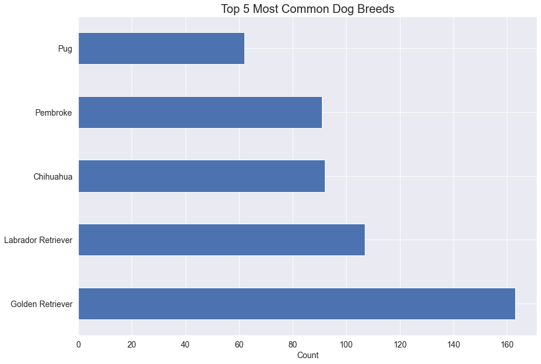

  The top 5 most common dog breeds are: Golden Retriever, Labrador Retriever, Chihuahua, Pembroke, Pug
- This visualization show the top 5 most retweeted dog breed ratings.

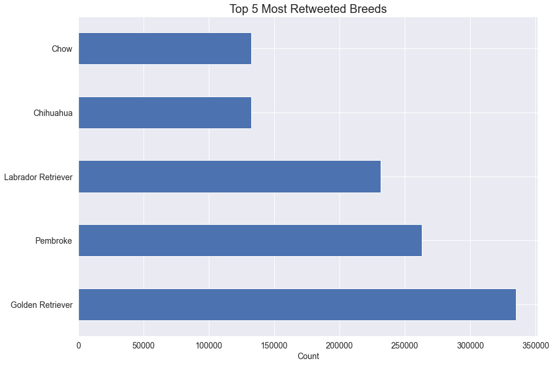

  Once again, Golden Retrievers are in the lead for retweets but the Labrador Retrievers lose their second place to the Pembrokes to settle for third. Chihuahuas and Chows make up the fourth and fifth places respectively.
- Last but certainly not least, here's an adorable picture of the Golden Retriever Father-Son duo who received the most love (retweets and favorites) for their troubles.

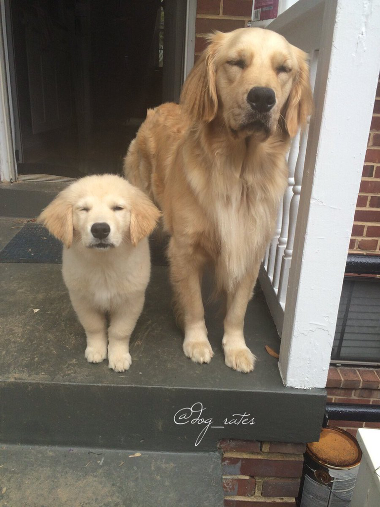